# FOS 2021 GENOME-WIDE ASSOCIATION ANALYSIS PRACTICAL

**Daniele Bizzarri, Erik van den Akker, Marian Beekman & Dina Vojinovic**

**November 2021**

## 1. INTRODUCTION

Genome-wide association study (GWAS) is a study design used to identify association between genetic variants and diseases or quantitative traits.[^1] Typically, GWAS is a hypothesis-free approach that involves looking for a single base-pair change in the DNA sequence (single nucleotide polymorphisms or SNPs) that occur with high frequency in the human genome.[^2] SNPs are said to be “associated” with disease/trait if certain SNPs are more commonly found in people with a disease/trait compared to those without the disease/trait. SNPs are typically used as markers of a genomic region, with most of them having a minimal impact on biological systems.[^3]

In this exercise, you will learn how to perform the genome-wide association analysis using rvtests. Rvtests is a comprehensive tool developed to support genetic association analysis. Details about rvtests can be found on http://zhanxw.github.io/rvtests/. The phenotype of interest in todays’ practical is a metabolically related quaternary ammonium compound measured in blood, betaine. Genetic data includes genotypes imputed with Haplotype Reference Consortium imputation panel.

## 2. INSTRUCTIONS

For this practical there are 2 assessment files: FOS_GWASpractical_20211124.html FOS_GWASpractical_20211124.RMD

You will use the html file to follow the practical, while you use the RMD file to run code that is required to answer the questions. Open the .html file on your browser by clicking over “FOS_GWASpractical_20211124.html” in the Files window of RStudio (bottom right) and pressing “View in Web Browser”.

Please, add your name, email and date on top of this file where it says “Insert your name here”, “Insert your email here” and “Insert the date here” and reply to the questions with your answers wherever you see the **A.**. At the end of the practical, please save this RMD file and upload this RMD file with the answers to Turnitin on Brightspace.

Load the libraries required for the practicals:

```r
library (data.table)
library(gap)
```

**Note:** Some of the packages might not have been installed yet. If receiving an error run: *install.packages (“gap”)* and try again.

## 3. GET FAMILIAR WITH DATA

You will receive 3 files:

1. Mydata.pheno
2. Mydata.covar
3. Mydata.vcf

### 3.1 PHENOTYPE DATA

By default, *.pheno file is a file with one line per sample and at least 6 columns as illustrated below:

- Column1: Study ID (‘fid’)
- Column2: Individual ID (‘iid’; cannot be ‘0’)
- Column3: ID of father (‘fatid’; ‘0’ if father isn’t in dataset)
- Column4: ID of mother (‘matid’; ‘0’ if mother isn’t in dataset)
- Column5: Sex (‘1’ = male, ‘2’ = female, ‘0’ = unknown)
- Column6: Phenotype1 (quantitative values or ‘1’ = control, ‘2’ = case, ‘0’ = missing)

The *.covar file has a similar format as the phenotype file. The first five columns are the same as in the *.pheno file. Additionally, other columns with relevant covariates are also included.

Open the phenotype and covariate files in the R-Studio cloud. Explore the files by using *dim* and looking at the first few entries, e.g:

```r
pheno <- read.table ("Mydata.pheno", header=TRUE, stringsAsFactors=F)
dim (pheno)
```

```
## [1] 3166    6
```

```r
head (pheno)
```

```
##    fid  iid fatid matid Sex  Betaine
## 1 1000 1000     0     0   2 66.30568
## 2 1001 1001     0     0   2 41.80708
## 3 1002 1002     0     0   2 57.77497
## 4 1003 1003     0     0   2 61.34421
## 5 1004 1004     0     0   1 38.20603
## 6 1005 1005     0     0   1 34.92115
```

```r
covar <- read.table ("Mydata.covar", header=TRUE, stringsAsFactors=F)
dim (covar)
```

```
## [1] 3166    6
```

```r
head (covar)
```

```
##    fid  iid fatid matid Sex       Age
## 1 1664 1664     0     0   2  96.25454
## 2 3129 3129     0     0   2  93.09233
## 3 3267 3267     0     0   2  93.80143
## 4 1678 1678     0     0   2  93.28124
## 5 1206 1206     0     0   1  97.17994
## 6 2962 2962     0     0   1 101.46467
```

**EXCERCISES**

**Q1.** How many individuals are in the dataset? What percentage is female?

```r
table (pheno$Sex)
```

**Q2.** Inspect variable betaine. Create descriptive statistics for this variable (mean, standard deviation, median, minimum, maximum) and generate histogram. What do the descriptive statistics look like?

```r
summary (pheno$Betaine)
sd (pheno$Betaine,na.rm=TRUE)
hist (pheno$Betaine, main = paste("Histogram of betaine - original variable"))
```

**Q3.** There may be several issues with this betaine variable? Why is this the case (look for missing values - strange number)? Correct these issues by setting the strange numbers of variable to missing (hint: check coding of missing values for quantitative trait in rvtests).

```r
pheno$Betaine[pheno$Betaine==999.99] <- NA
```

**Q4.** Check descriptive statistics and generate a histogram of variable betaine again. Inspect the output. Is the variable normally distributed? Should we apply normalization? How should we treat this variable?

```r
hist (pheno$Betaine, main = paste("Histogram of betaine - corrected variable"))
```

**Q5.** Now normalize the betaine variable by inverse rank transformation. To create a new variable, you could use code below. Generate a histogram of normalized variable and inspect the normalized values.

```r
pheno$Betaine_rank<- qnorm((rank(pheno$Betaine,na.last="keep")-0.5)/sum(!is.na(pheno$Betaine)))
hist (pheno$Betaine_rank, main = paste("Histogram of betaine - rank transformed"))
```

### 3.2. GENOTYPE DATA

By default, the *.vcf (Variant Call Format) file is a file format for storing genetic variation data. Even though VCF files are text files, they tend to be rather big. Therefore, for purposes of this exercise, you will explore a small example VCF file - Mydata.vcf.

In the web browser open the page https://samtools.github.io/hts-specs/VCFv4.2.pdf. This webpage is describing the VCF format and contains very useful information. The facts about the VCF files are as follows:

- The VCF file starts with multiple meta-information lines (staring with ##). These lines describe what information can be found in the VCF. Not all VCF files contain the same information, therefore, the headers of two VCFs can be completely different.
- Subsequently, the VCF file contains single header line (starting with #). The header line names the 8 fixed, mandatory columns. These columns are as follows:
  - CHROM - chromosome
  - POS - position (genomic coordinate on which the variant occurs)
  - ID - an optional unique identifier (typically the dbSNP variants identifier - rs number)
  - REF - reference base; the base listed in the reference genome
  - ALT - alternate base; the base observed in a sample/samples
  - QUAL - quality score
  - FILTER - filter status; PASS if position has passed all filters
  - INFO - additional information. Check the web page for data type.
- After these mandatory columns, the VCF file could contain genotype information. The same type of data must be present for all samples. This is specified in FORMAT field. If present, the first sub-field of FORMAT field must always be genotype (GT). Check the web page for other data type. Subsequently, you will find the ID names of the samples in the VCF file.
- Following the header are the data line containing information about a position in the genome.

Open Mydata.vcf file in R and answer the questions.

```r
# Read header of the file
vcf_header <- readLines("Mydata.vcf")
head(vcf_header)
```

```
## [1] "##fileformat=VCFv4.0"
## [2] "##fileDate=20090805"
## [3] "##source=myImputationProgramV3.1"
## [4] "##reference=1000GenomesPilot-NCBI36"
## [5] "##phasing=partial"
## [6] "##INFO=<ID=NS,Number=1,Type=Integer,Description=\"Number of Samples With Data\">"
```

```r
# Read the file
vcf <- fread ("Mydata.vcf")
head (vcf)
```

```
##    #CHROM     POS        ID REF ALT QUAL FILTER
## 1:     19     111         .   A   C  9.6      .
## 2:     19     112         .   A   G   10      .
## 3:     20   14370 rs6054257   G   A   29   PASS
## 4:     20   17330         .   T   A    3    q10
## 5:     20 1110696 rs6040355   A G,T   67   PASS
## 6:     20 1230237         .   T   .   47   PASS
##                                 INFO      FORMAT        NA00001        NA00002
## 1:                                 .       GT:HQ      0|0:10,10      0|0:10,10
## 2:                                 .       GT:HQ      0|0:10,10      0|0:10,10
## 3:           NS=3;DP=14;AF=0.5;DB;H2 GT:GQ:DP:HQ 0|0:48:1:51,51 1|0:48:8:51,51
## 4:               NS=3;DP=11;AF=0.017 GT:GQ:DP:HQ 0|0:49:3:58,50   0|1:3:5:65,3
## 5: NS=2;DP=10;AF=0.333,0.667;AA=T;DB GT:GQ:DP:HQ 1|2:21:6:23,27   2|1:2:0:18,2
## 6:                   NS=3;DP=13;AA=T GT:GQ:DP:HQ 0|0:54:.:56,60 0|0:48:4:51,51
##         NA00003
## 1:      0/1:3,3
## 2:      0/1:3,3
## 3: 1/1:43:5:.,.
## 4: 0/0:41:3:.,.
## 5: 2/2:35:4:.,.
## 6: 0/0:61:2:.,.
```

**EXCERCISES**

**Q6.** What are the sub-fields included in the FORMAT field in the Mydata.vcf file? (hint: check header of the file)  
**Q7.** What is the ID name of first two samples listed in the Mydata.vcf file?  
**Q8.** What are the position of the first two variants listed in the VCF file? What are the reference and alternative bases for these variants?  
**Q9.** How are genotypes encoded in the VCF file? What are the allele values for reference and alternative alleles?  
**Q10.** What is the genotype of first person for the first variant?

## 4. QUALITY CONTROL PRIOR GWAS

A crucial step of any GWAS is the use of appropriate quality control (QC). The QC is typically applied at the sample and SNP-specific level. In this paragraph we will focus on sample-level QC, while SNP-level QC will be discussed later. Sample-level QC includes filtering out samples with low call rates, evidence for different ethnic origin,relatedness/duplication, sex discrepancies and genotyping batch effects. Without extensive QC, GWAS will not generate reliable results. Here, we will provide details on the effects of different ethnic origin, relatedness and sex discrepancies in GWAS.

1. Evidence of different ethnic origin - Population stratification occurs when the study samples comprise multiple groups of individuals who differ systematically in both genetic ancestry and the phenotype under investigation. Differences in ancestry would lead to spurious associations rather than true association of alleles to disease.There are several methods for observing and clustering ancestral groups. These methods use genome-wide level data to summarize genetic variance in variables that can be plotted to visualize genetic relationships between samples. When visualized alongside known reference populations, ancestral background can be identified among the sample. Below you will find a multidimensional scaling (MDS) plot. The study population is shown in red while color of other ancestral groups is displayed in the legend.

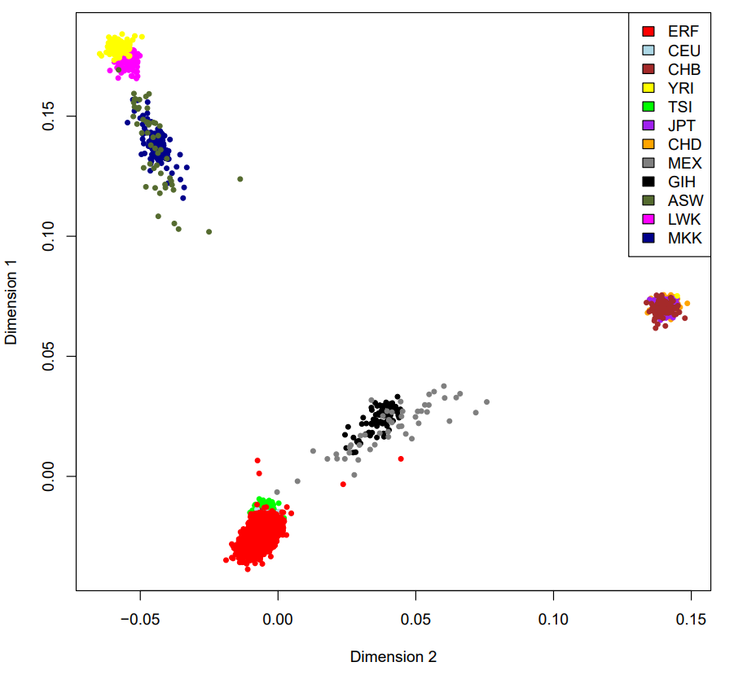

MDS plot

2. Sample relatedness - The statistical association between genotypes and phenotypes could be biases by sample relatedness. Therefore, differences in the levels of relatedness need to be accounted for in GWAS.
3. Sex discrepancies refer to difference between the sex recorded in the dataset and sex based on genotypes of sex chromosomes (X and Y). Sex discrepancies can indicate sample mix-ups. Sex discrepancy checks can also reveal sex chromosomal anomalies such as Turner syndrome (females having karyotype XO), Kleinfelter syndrome (males having karyotype XXY) etc.

**EXCERCISES**

**Q11.** Could you think of some strategies for avoiding bias induced by population stratification?  
**Q12.** Are there any samples that represent ethnic outlines on mdsplot? How would you deal with those samples in the GWAS?  
**Q13.** Does rvtests deal with related sample and how (hint: check webpage)?  
**Q14.** Would you consider returning findings of sex chromosomal anomalies to individual if discovered during the sex-checks? What is the rationale behind this?

## 5. ASSOCIATION ANALYSIS

Standard approach to identify genetic variants associated with phenotype in GWAS is linear or logistic regression. Statistical model for each SNP would be linear or logistic regression of phenotype on genotype while correcting for covariates.

The model for GWAS of betaine is as follows:

Betaine ~ constant + β1 x SNP + β2 x age + β3 x sex

**EXCERCISE**

**Q15.** Based on the coding of the SNP in Mydata.vcf, additive model will be tested.If you would like to run dominant or recessive model, how would you recode the genotypes?  
**Q16.** As indicated in the model, covariates are age and sex.Are these confounders in the classical sense? If not, why would you still want to adjust for confounders in GWAS?

## 6. INSPECTION OF OUTPUT FILES

The summary statistics will be stored in the output file with each line representing a SNP. As output files contain hundreds of thousands to millions of SNPs, the size of the file is rather big. For the purposes of this exercise, you will receive the subset of original summary statistic results (Myresults.txt.gz). Open this file in R-Studio Cloud.

```r
results <- read.table (gzfile("Myresults.txt.gz"),header=TRUE, stringsAsFactors=F)

results[1:5,1:16]
```

```
##                ID CHROM       POS REF ALT N_INFORMATIVE          AF
## 1 5:100000088_A_G     5 100000088   A   G          2158 2.62362e-05
## 2 5:100000105_G_A     5 100000105   G   A          2158 2.07147e-04
## 3 5:100000106_C_T     5 100000106   C   T          2158 2.80809e-04
## 4  5:10000023_G_A     5  10000023   G   A          2158 9.89766e-01
## 5 5:100000231_A_G     5 100000231   A   G          2158 5.37431e-04
##   INFORMATIVE_ALT_AC CALL_RATE HWE_PVALUE N_REF N_HET N_ALT      U_STAT
## 1              0.103         1          1  2158     0     0   0.0116505
## 2              0.946         1          1  2158     0     0  -0.0147770
## 3              1.224         1          1  2158     0     0  -0.0439538
## 4           4271.880         1          1     0    42  2116 -11.3144000
## 5              2.354         1          1  2158     0     0   0.5814470
##   SQRT_V_STAT ALT_EFFSIZE
## 1   0.0327322   10.874100
## 2   0.3162780   -0.147723
## 3   0.3205260   -0.427828
## 4   6.3438100   -0.281146
## 5   0.5572450    1.872480
```

In this file, you will obtain following columns:

- N_INFORMATIVE - Number of samples that are analyzed for association
- AF - Allele frequency
- INFORMATIVE_ALT_AC - The number of alternative alleles in the analyzed samples
- CALL_RATE - The fraction of non-missing alleles
- HWE_PVALUE - Hardy-Weinberg equilibrium
- N_REF/N_HET/N_ALT - Number of samples carrying homozygous reference /heterozygous/ homozygous alternative alleles
- U_STAT, SQRT_V_STAT - U and V statistics are score statistics and their covariance matrix
- ALT_EFFSIZE - Estimated effect size (continuous outcomes) or log odds-ratio (binary outcome)

**EXCERCISES**

**Q17.** How many samples are analyzed for association? How many SNPs are included in Myresults.txt.gz file? Which chromosomes are these SNPs mapped to?

```r
dim (results)
table(results$CHROM)
```

**Q18.** How many genome-wide significant variants are in Myresults.txt.gz file?

```r
dim(results[which(results$PVALUE<0.00000005),])
```

## 7. VISUALIZATION

Visualization of GWAS results is necessary to get the overview of large amount of information and to be able to interpret the results. Typically, QQ plot, Manhattan plot, and LocusZoom plot are made after the GWAS.

### 7.1 QQ PLOT

The QQ plot is a plot representing the deviation of the observed p-values plotted against expected p-values from a theoretical χ2-distribution. If the observed values correspond to the expected values, all points are on or near the middle line between the x- and y-axis. In a case some observed p-values are more significant than expected, points will move towards the y-axis. QQ plot based on Myresults.txt.gz can be generated using the code below.

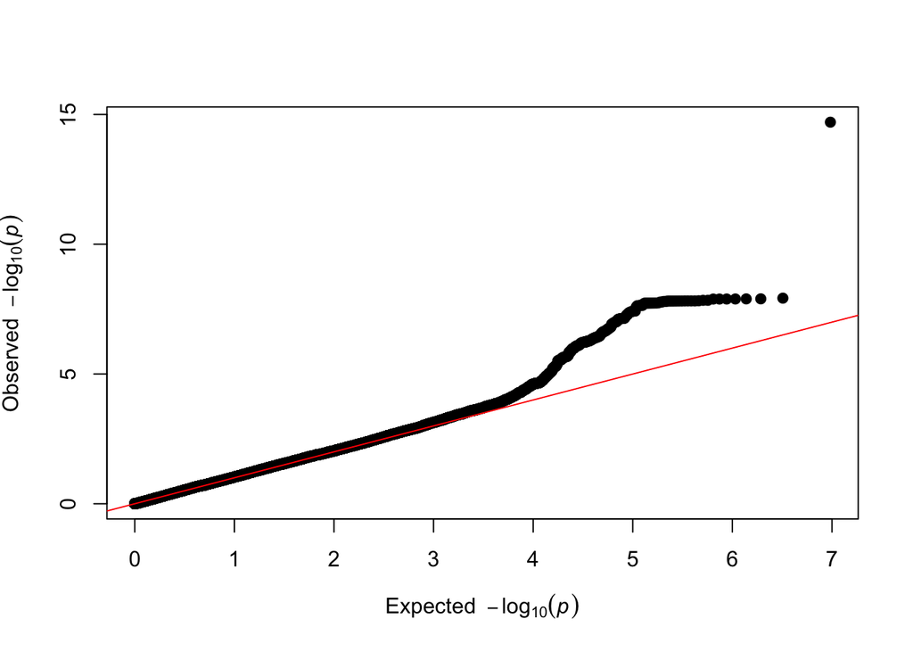

```r
qq = function(pvector, ...) { if (!is.numeric(pvector)) stop("D'oh! P value vector is not numeric.")
pvector <- pvector[!is.na(pvector) & pvector<1 & pvector>0]
o = -log10(sort(pvector,decreasing=F))
e = -log10(ppoints(length(pvector) ))
plot(e,o,pch=19,cex=1,xlab=expression(Expected~~-log[10](italic(p))),ylab=expression(Observed~~-log[10](italic(p))), xlim=c(0,max(e)),
ylim=c(0,max(o)), ...)
abline(0,1,col="red") }

qq(results$PVALUE)
```

**EXCERCISES**

**Q19.** Check the QQ plot. Does it look acceptable?  
**Q20.** A QQ plot made with the data of different study and different quantitative trait is displayed below.

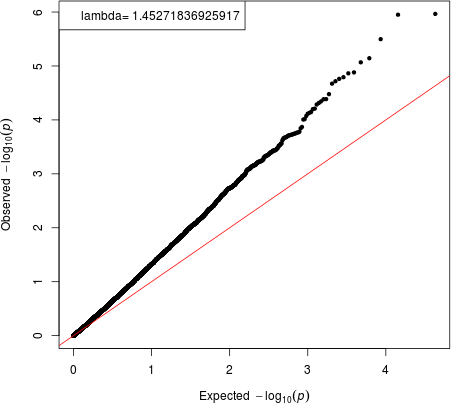

QQ plot

Is the quality of the GWAS acceptable according to this QQ plot? If not, what are the reasons?

Additionally, the deviation of the distribution of the observed test statistic compared to the distribution of the expected test statistic can also be quantified. Common way to do this is to calculate genomic inflation factor, also known as lambda gc (λgc). By definition, λgc is defined as the median of the resulting chi-squared test statistics divided by the expected median of the chi-squared distribution.

**EXCERCISES**

**Q21.** Calculate the inflation factor. How do you interpret it?

```r
results$SE <- 1/results$SQRT_V_STAT
chi2 <- (results$ALT_EFFSIZE/results$SE)^2
lam <- median(sort(chi2))/qchisq(0.5,1)
```

### 7.2 MANHATTAN PLOT

The Manhattan plot displays chromosomal position on the X axis and negative log of the p-value for the association test on the Y axis. Each point on the plot represents a SNP. Use the R code below to visualize the Myresults.txt.gz.

```r
library (gap)
# select chromosome,position, and p-value name
results1<-results[,c("CHROM","POS","PVALUE")]
# change names to work with the functions
names(results1) <- c("chr","pos","p")
# remove NA's
results1<-results1[!is.na(results1$p),]
# order the file
results1 <- results1[order(results1[,1], results1[,2]),]

# if you have 22 chromosome change to: color <- rep(c("blue","red"),11)
color <- rep(c("blue","red"),1)
# for 22 chrom, change labels to: labels=1:22
ops <- mht.control(colors=color,yline=1.5,xline=1,labels=c(5,6),srt=270)
mhtplot(results1[,c("chr","pos","p")],ops,xlab="chromosomes",ylab="-log p-value",srt=0)
```

```
## Plotting points  1 - 2483444
## Plotting points  2483445 - 4823069
```

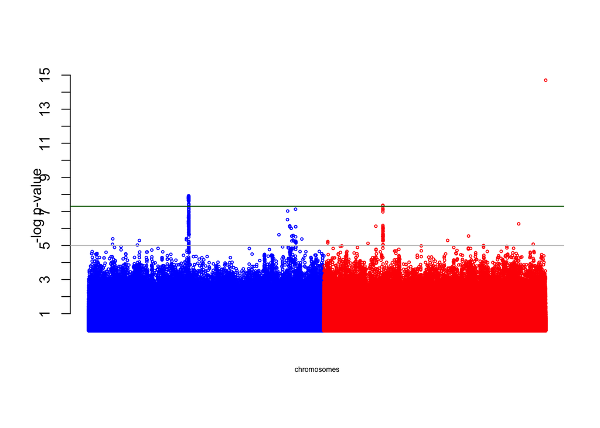

```r
axis(2,at=1:round(max(-log10(results1$p))))
abline(h=5,col="grey",lty=1)
abline(h=-log10(0.00000005),col="dark green",lty=1)
```

```r
rm(results1)
gc()
```

```
##             used   (Mb) gc trigger   (Mb) limit (Mb)  max used   (Mb)
## Ncells   9908196  529.2   32128370 1715.9         NA  34702260 1853.4
## Vcells 211234270 1611.6  366130371 2793.4      16384 305041975 2327.3
```

**EXCERCISES**

**Q22.** What is the p-value threshold of the dark green line?  
**Q23.** Is there any SNP genome widely significantly associated with betaine? If yes, where is it located?

```r
head(results[order(results$PVALUE),])
```

**Q24.** Does top hit make sense?

### 7.3 LOCUS ZOOM PLOT

The Locus Zoom plot displays association results of a region. Region showing association with the phenotype of interest can be visually inspected to determine the extent of association signal and the position relative to nearby genes. To plot the data, you will use an online tool, locus zoom (http://locuszoom.org/). This tool accepts a file with following information for each variant: chromosome, position, reference and alt alleles, and p-value (or -log10 p). The file has already been uploaded to the website. Follow the steps below to explore the regional plot for the top SNP:

- Go to the webpage: https://my.locuszoom.org/gwas/117508/?token=88e05567fddd40308b22b2b14ae70560
- Click on any peak in the Manhattan plot to jump to a specific LocusZoom region view

**EXERCISES**

**Q25.** How does the locus zoom plot look like for the top SNP? Is there linkage disequilibrium between the top SNP and other SNP of the same region?  
**Q26.** Go back to the results file and check the imputation quality, allele frequency and HWE of this top SNP. Is this SNP reliable?

```r
results[which(results$ID=="6:171048850_T_C"),]
```

## 8. POST GWAS QUALITY CONTROL

The post GWAS QC is typically applied at the SNP-specific level and it consists of filtering out non reliable SNPs based on allele frequency, Hardy–Weinberg equilibrium (HWE), call rate and imputation quality.

1. Most GWAS studies begin by filtering the variants by the allele frequency (AF). Variant with a low minor AF (MAF) are rare and therefore power for detecting association with phenotype of interest is lacking. Also, these variants are prone to genotyping errors. Typically, the MAF threshold depends on the size of study population. Commonly used thresholds are 0.01 and 0.05.
2. HWE is a fundamental principal of population genetics, which states that “genotype frequencies in a population remain constant between generations in the absence of disturbance by outside factors”. Typically, SNPs deviating from Hardy–Weinberg equilibrium are excluded.
3. Call rate for a given SNP is defined as the proportion of individuals in the study for which the corresponding SNP information is not missing. A high rate of missing data at a SNP locus is considered an indication of inaccurate genotype calls. A standard rule is filtering for SNPs with call rates ≥95 or 99%.
4. Imputation quality - Commercial SNP genotyping arrays do not have complete coverage of the human genome. Therefore, to improve both coverage and power of a GWAS we use genotype imputation. Based on the linkage disequilibrium (LD) patterns derived from directly genotyped markers and comparing them to a suitable reference population, the alleles of ungenotyped SNPs can be inferred. Imputation quality can be assessed by the internal quality metrics obtained from each imputation protocol. These values range from 0 to 1, where a higher value indicates increased quality of an imputed SNP.

**EXERCISES**

**Q27.** How many SNPs with MAF < 0.01 are in your dataset?

```r
dim(results[which(results$AF<0.01 | results$AF>0.99),])
```

**Q28.** What is AF of 5:12180_T_G SNP? How many carriers of minor allele are present in your data?

```r
results[which(results$ID=="5:12180_T_G"),]
```

**Q29.** What are the lowest p-value for HWE test, the lowest imputation quality and call rate in Myresults.txt.gz?

```r
head(results[order(results$HWE_PVALUE),])
head(results[order(results$CALL_RATE),])
head(results[order(results$Rsq),])
```

**Q30.** How many SNPs are out of HWE if you use a p-value threshold of 0.000001? Which factors can cause deviation from HWE?

```r
dim(results[order(results$HWE_PVALUE<0.000001),])
```

**Q31.** How many SNPs do you filter out based on MAF < 0.01, call rate of 95%, HWE p-value of 0.000001 or imputation quality of 0.3?  
**Q32.** Create a file listing all SNPs that passed above mentioned SNP-specific level filters. How many genome wide significant variants are there in your meta-analysis after performing the QC?  
**Q33.** Create Manhattan, QQ and locus zoom plots using the QC-ed result file. The QC’ed file has been uploaded to the locus zoom website. Go to https://my.locuszoom.org/gwas/571690/?token=55852dc8d8514c6481e76807dbf41d6f to generate regional plots for your top findings. Do you notice any difference between plots generated based on non-QC-ed and QC-ed summary statistic results?  
**Q34.** Where are your top SNPs located?

## 9. ANNOTATION

You will do annotation based on the top significant SNPs you found in this exercise.

https://genome.ucsc.edu/cgi-bin/hgVai  
http://www.genecards.org/  
https://www.ebi.ac.uk/gwas/

**EXERCISES**

**Q35.** Do the results make any sense given that the trait is circulating level of betaine? (hint: What is the function of the top genes?)  
**Q36.** Which pathways are these genes involved in?  
**Q37.** Did any other GWAS find the similar answer as you did?

## 10. VALIDATION STUDIES

The value of finding is reliant on the ability to replicate it in an independent cohort. Successful replication minimizes the likelihood that reported findings are false positive.

**EXERCISES**

**Q38.** Would you use similar of different population for replication and why?  
**Q39.** Which SNPs would you select for replication and why?  
**Q40.** Would you involve meta-analysis of the original summary? statistic results and the results from validation study and why?

[^1]: Tam, Vivian, et al. “Benefits and limitations of genome-wide association studies.” Nature Reviews Genetics 20.8 (2019): 467-484.
[^2]: Genomes Project Consortium (2010) A map of human genome variation from population-scale sequencing. Nature 467: 1061–1073 .
[^3]: Bush, William S., and Jason H. Moore. “Chapter 11: Genome-wide association studies.” PLoS computational biology 8.12 (2012): e1002822.